# Statistical Learning B: Final Project

## 2.2 Model diagnostics

Now, we use this model for prediction in order to assess its classification accuracy.

We are particularly interested in how well the model is able to identify diabetic subjects; since these results will likely be used for identifying good prevention practices rather than as a diagnostic tool (and, even then, the diagnosis would have to be confirmed through clinical test), we are not particularly worried about identifying a patient as sick when she is not - while we do care about identifying all truly sick patients as sick.

Hence, we are interested in calculating the sensitivity and precision of our model, which are reported below.

```r
#Prediction and confusion matrix for full model (p=0.5)

dim(test.data)
```

```
## [1] 178  27
```

```r
log_prob <- predict(log_reg, test.data, type = 'response')
logistic_pred <- rep(0, dim(test.data)[1])
logistic_pred[log_prob>0.5] <- 1
full_confusion <- confusionMatrix(data=as.factor(logistic_pred), reference = as.factor(test.data$Diabetic), positive = '1')
full_confusion
```

```
## Confusion Matrix and Statistics
##
##           Reference
## Prediction   0   1
##          0 119  13
##          1   4  42
##
##                Accuracy : 0.9045
##                  95% CI : (0.8515, 0.9434)
##     No Information Rate : 0.691
##     P-Value [Acc > NIR] : 9.189e-12
##
##                   Kappa : 0.7658
##
##  Mcnemar's Test P-Value : 0.05235
##
##             Sensitivity : 0.7636
##             Specificity : 0.9675
##          Pos Pred Value : 0.9130
##          Neg Pred Value : 0.9015
##              Prevalence : 0.3090
##          Detection Rate : 0.2360
##    Detection Prevalence : 0.2584
##       Balanced Accuracy : 0.8656
##
##        'Positive' Class : 1
##
```

Next, we visualize the ROC curve for this model in order to observe its performance.

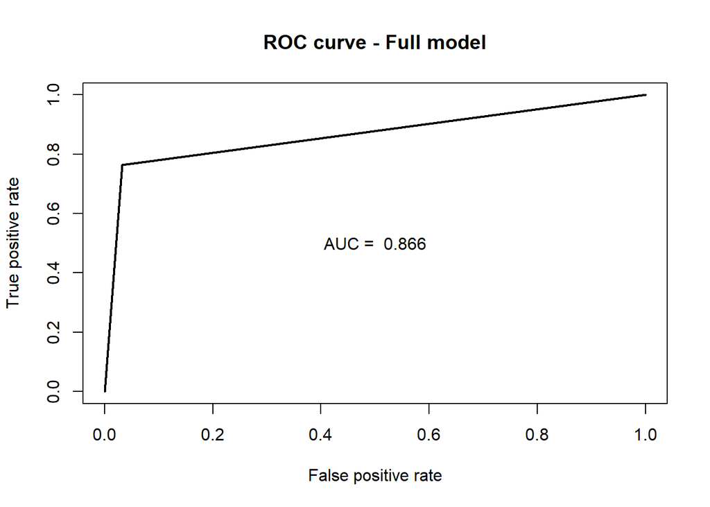

```r
full_prediction <- prediction(logistic_pred, test.data$Diabetic)

roc_curve_full <- performance(full_prediction, measure="tpr", x.measure = "fpr" )

auc <- performance(full_prediction, measure="auc")

auc <- auc@y.values[[1]]

auc <- as.character(round(auc, 3))

p <- plot(roc_curve_full, lwd = 2, main = "ROC curve - Full model")

full_auc = paste("AUC = ", auc)
text(0.5, 0.5, full_auc)
```

```r
# (Testing) error rate among diabetic subjects with p=0.5

table(logistic_pred, test.data$Diabetic)
```

```
##
## logistic_pred   0   1
##             0 119  13
##             1   4  42
```

```r
FN = table(logistic_pred, test.data$Diabetic)[1,2]
TP = table(logistic_pred, test.data$Diabetic)[2,2]
err_05 = FN/(FN+TP)
err_05 #0.2363636
```

```
## [1] 0.2363636
```

```r
#Prediction and confusion matrix for full model (p=0.1)

dim(test.data)
```

```
## [1] 178  27
```

```r
log_prob <- predict(log_reg, test.data, type = 'response')
logistic_pred_01 <- rep(0, dim(test.data)[1])
logistic_pred_01[log_prob>0.1] <- 1
full_confusion_01 <- confusionMatrix(data=as.factor(logistic_pred_01), reference = as.factor(test.data$Diabetic), positive = '1')
full_confusion_01
```

```
## Confusion Matrix and Statistics
##
##           Reference
## Prediction  0  1
##          0 98  2
##          1 25 53
##
##                Accuracy : 0.8483
##                  95% CI : (0.787, 0.8976)
##     No Information Rate : 0.691
##     P-Value [Acc > NIR] : 1.060e-06
##
##                   Kappa : 0.6816
##
##  Mcnemar's Test P-Value : 2.297e-05
##
##             Sensitivity : 0.9636
##             Specificity : 0.7967
##          Pos Pred Value : 0.6795
##          Neg Pred Value : 0.9800
##              Prevalence : 0.3090
##          Detection Rate : 0.2978
##    Detection Prevalence : 0.4382
##       Balanced Accuracy : 0.8802
##
##        'Positive' Class : 1
##
```

```r
# (Testing) error rate among diabetic subjects with p=0.1

table(logistic_pred_01, test.data$Diabetic)
```

```
##
## logistic_pred_01  0  1
##                0 98  2
##                1 25 53
```

```r
FN = table(logistic_pred_01, test.data$Diabetic)[1,2]
TP = table(logistic_pred_01, test.data$Diabetic)[2,2]
err_01 = FN/(FN+TP)
err_01 #0.03636364
```

```
## [1] 0.03636364
```

Here, we plot the ROC curve for the model with p=0.1, for comparison.

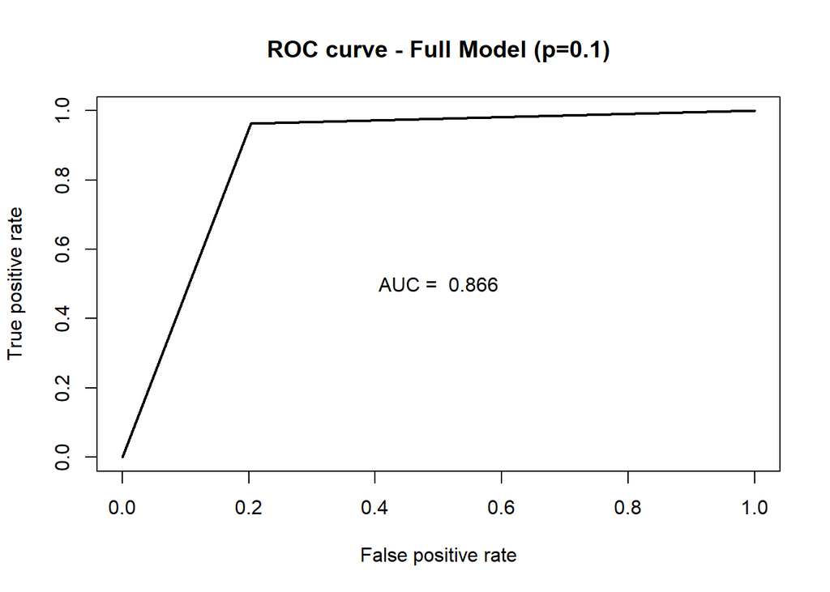

```r
full_prediction_01 <- prediction(logistic_pred_01, test.data$Diabetic)

roc_curve_full_01 <- performance(full_prediction_01, measure="tpr", x.measure = "fpr" )

auc <- performance(full_prediction_01, measure="auc")

auc <- auc@y.values[[1]]

auc <- round(auc, 3)

plot(roc_curve_full_01, main="ROC curve - Full Model (p=0.1)", lwd=2)

auc_best_full = paste("AUC = ", auc)

text(0.5, 0.5, full_auc)
```